# Functions in R: Summary Statistics and Two-Sample t-Test

Manzi Joel (Student ID: 20252MBI024)

2026-11-19

## 1. Aim

Class exercises:

1. Make functions that calculate summary statistics, and apply them to a variable to show that they work.
2. Make a function that calculates a two-sample t-test, and apply it to data.

All functions below use only basic R operations (`sum()`, `length()`, `sqrt()`, `sort()`). At the end of each part, we compare our results with R’s built-in functions to show they are correct.

## 2. Data

We use the built-in `mtcars` data (32 cars).

- `mpg`: miles per gallon (fuel efficiency)
- `am`: transmission type (0 = automatic, 1 = manual)

```r
data(mtcars)
head(mtcars[, c("mpg", "am")])
```

```
##                    mpg am
## Mazda RX4         21.0  1
## Mazda RX4 Wag     21.0  1
## Datsun 710        22.8  1
## Hornet 4 Drive    21.4  0
## Hornet Sportabout 18.7  0
## Valiant           18.1  0
```

# Part A: Summary statistics functions

## 3. Writing the functions

```r
# Mean: sum of values divided by the number of values
my_mean <- function(x) {
  x <- x[!is.na(x)]
  sum(x) / length(x)
}

# Median: middle value of the sorted data
my_median <- function(x) {
  x <- sort(x[!is.na(x)])
  n <- length(x)
  if (n %% 2 == 1) {
    x[(n + 1) / 2]
  } else {
    (x[n / 2] + x[n / 2 + 1]) / 2
  }
}

# Mode: the value that appears most often
my_mode <- function(x) {
  x <- x[!is.na(x)]
  counts <- table(x)
  as.numeric(names(counts)[counts == max(counts)])
}

# Sample variance: sum of squared differences from the mean, divided by (n - 1)
my_var <- function(x) {
  x <- x[!is.na(x)]
  sum((x - my_mean(x))^2) / (length(x) - 1)
}

# Standard deviation: square root of the variance
my_sd <- function(x) {
  sqrt(my_var(x))
}

# Range: maximum minus minimum
my_range <- function(x) {
  x <- sort(x[!is.na(x)])
  x[length(x)] - x[1]
}

# Quantile (same method as R's default, type 7)
my_quantile <- function(x, p) {
  x <- sort(x[!is.na(x)])
  n <- length(x)
  h <- (n - 1) * p + 1
  lower <- floor(h)
  upper <- ceiling(h)
  x[lower] + (h - lower) * (x[upper] - x[lower])
}

# Interquartile range: Q3 minus Q1
my_iqr <- function(x) {
  my_quantile(x, 0.75) - my_quantile(x, 0.25)
}

# Coefficient of variation (%): how big the SD is compared to the mean
my_cv <- function(x) {
  my_sd(x) / my_mean(x) * 100
}

# One function that returns all summary statistics together
my_summary <- function(x) {
  x <- x[!is.na(x)]
  sorted <- sort(x)
  data.frame(
    n      = length(x),
    mean   = my_mean(x),
    median = my_median(x),
    sd     = my_sd(x),
    var    = my_var(x),
    min    = sorted[1],
    Q1     = my_quantile(x, 0.25),
    Q3     = my_quantile(x, 0.75),
    max    = sorted[length(sorted)],
    range  = my_range(x),
    IQR    = my_iqr(x),
    CV_pct = my_cv(x)
  )
}
```

## 4. Applying the functions to a variable

We apply the functions to `mpg`.

```r
round(my_summary(mtcars$mpg), 3)
```

```
##    n   mean median    sd    var  min     Q1   Q3  max range   IQR CV_pct
## 1 32 20.091   19.2 6.027 36.324 10.4 15.425 22.8 33.9  23.5 7.375 29.999
```

```r
my_mode(mtcars$mpg)
```

```
## [1] 10.4 15.2 19.2 21.0 21.4 22.8 30.4
```

The mode returns more than one value because several `mpg` values appear twice.

## 5. Check against R’s built-in functions

```r
check <- data.frame(
  statistic = c("mean", "median", "variance", "sd", "Q1", "Q3", "IQR", "range"),
  my_function = c(my_mean(mtcars$mpg), my_median(mtcars$mpg), my_var(mtcars$mpg),
                  my_sd(mtcars$mpg), my_quantile(mtcars$mpg, 0.25),
                  my_quantile(mtcars$mpg, 0.75), my_iqr(mtcars$mpg),
                  my_range(mtcars$mpg)),
  built_in = c(mean(mtcars$mpg), median(mtcars$mpg), var(mtcars$mpg),
               sd(mtcars$mpg), quantile(mtcars$mpg, 0.25),
               quantile(mtcars$mpg, 0.75), IQR(mtcars$mpg),
               diff(range(mtcars$mpg)))
)
check$same <- abs(check$my_function - check$built_in) < 1e-10
check
```

```
##   statistic my_function  built_in same
## 1      mean   20.090625 20.090625 TRUE
## 2    median   19.200000 19.200000 TRUE
## 3  variance   36.324103 36.324103 TRUE
## 4        sd    6.026948  6.026948 TRUE
## 5        Q1   15.425000 15.425000 TRUE
## 6        Q3   22.800000 22.800000 TRUE
## 7       IQR    7.375000  7.375000 TRUE
## 8     range   23.500000 23.500000 TRUE
```

All values are the same, so our functions work. They also work on another variable and with missing values:

```r
x_with_na <- c(mtcars$hp, NA)
round(my_summary(x_with_na), 3)
```

```
##    n    mean median     sd      var min   Q1  Q3 max range  IQR CV_pct
## 1 32 146.688    123 68.563 4700.867  52 96.5 180 335   283 83.5 46.741
```

# Part B: Two-sample t-test function

## 6. Theory

We want to know if the means of two independent groups are different.

- H0: mean of group 1 = mean of group 2
- H1: mean of group 1 is not equal to mean of group 2

Our function does two versions:

- **Welch t-test** (default): does not assume the two groups have equal variance.
  - t = (mean1 - mean2) / sqrt(s1²/n1 + s2²/n2)
  - degrees of freedom from the Welch-Satterthwaite formula
- **Pooled (Student) t-test**: assumes equal variance.
  - pooled variance sp² = ((n1 - 1)s1² + (n2 - 1)s2²) / (n1 + n2 - 2)
  - t = (mean1 - mean2) / sqrt(sp² (1/n1 + 1/n2)), df = n1 + n2 - 2

The p-value comes from the t distribution (`pt()`), and the 95% confidence interval uses `qt()`.

## 7. Writing the function

```r
my_t_test <- function(x, y, var_equal = FALSE, conf_level = 0.95) {
  x <- x[!is.na(x)]
  y <- y[!is.na(y)]
  n1 <- length(x); n2 <- length(y)
  m1 <- my_mean(x); m2 <- my_mean(y)
  v1 <- my_var(x);  v2 <- my_var(y)

  if (var_equal) {
    sp2 <- ((n1 - 1) * v1 + (n2 - 1) * v2) / (n1 + n2 - 2)
    se  <- sqrt(sp2 * (1 / n1 + 1 / n2))
    df  <- n1 + n2 - 2
    method <- "Two-sample t-test (pooled, equal variances)"
  } else {
    se <- sqrt(v1 / n1 + v2 / n2)
    df <- (v1 / n1 + v2 / n2)^2 /
          ((v1 / n1)^2 / (n1 - 1) + (v2 / n2)^2 / (n2 - 1))
    method <- "Welch two-sample t-test (unequal variances)"
  }

  t_stat  <- (m1 - m2) / se
  p_value <- 2 * pt(-abs(t_stat), df)
  t_crit  <- qt(1 - (1 - conf_level) / 2, df)
  ci      <- (m1 - m2) + c(-1, 1) * t_crit * se

  result <- list(method = method, mean_x = m1, mean_y = m2,
                 difference = m1 - m2, t = t_stat, df = df,
                 p_value = p_value, conf_int = ci, conf_level = conf_level)
  class(result) <- "my_ttest"
  result
}

# Print method so the result is easy to read
print.my_ttest <- function(r, ...) {
  cat(r$method, "\n")
  cat("Mean of x:", round(r$mean_x, 4), " Mean of y:", round(r$mean_y, 4), "\n")
  cat("Difference (x - y):", round(r$difference, 4), "\n")
  cat("t =", round(r$t, 4), ", df =", round(r$df, 4),
      ", p-value =", signif(r$p_value, 4), "\n")
  cat(r$conf_level * 100, "% confidence interval: [",
      round(r$conf_int[1], 4), ",", round(r$conf_int[2], 4), "]\n")
  cat(ifelse(r$p_value < 0.05,
             "Decision: reject H0 at the 5% level (the means are different).",
             "Decision: do not reject H0 at the 5% level."), "\n")
  invisible(r)
}
```

## 8. Applying the function to data

**Question:** do manual cars and automatic cars have different fuel efficiency (`mpg`)?

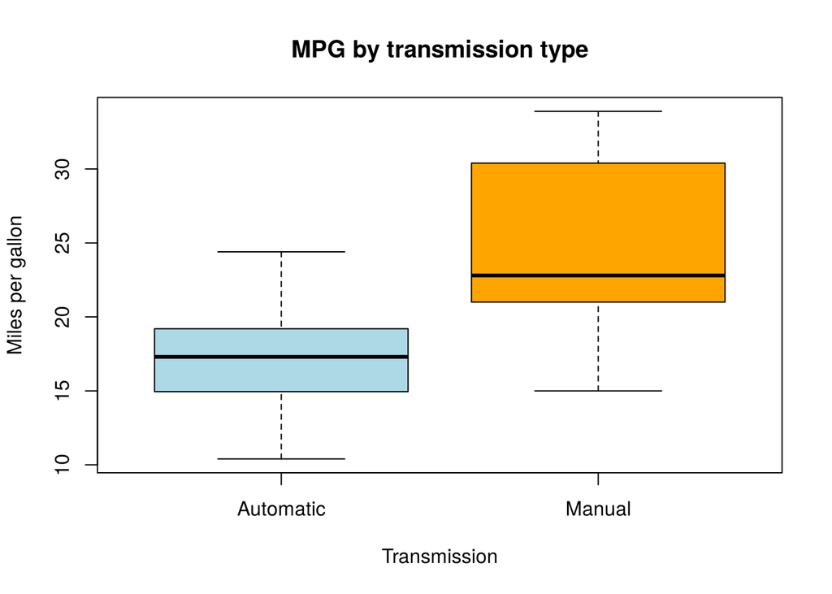

```r
manual    <- mtcars$mpg[mtcars$am == 1]
automatic <- mtcars$mpg[mtcars$am == 0]

boxplot(mpg ~ factor(am, labels = c("Automatic", "Manual")), data = mtcars,
        col = c("lightblue", "orange"), xlab = "Transmission",
        ylab = "Miles per gallon", main = "MPG by transmission type")
```

```r
welch  <- my_t_test(manual, automatic)
welch
```

```
## Welch two-sample t-test (unequal variances)
## Mean of x: 24.3923  Mean of y: 17.1474
## Difference (x - y): 7.2449
## t = 3.7671 , df = 18.3323 , p-value = 0.001374
## 95 % confidence interval: [ 3.2097 , 11.2802 ]
## Decision: reject H0 at the 5% level (the means are different).
```

```r
pooled <- my_t_test(manual, automatic, var_equal = TRUE)
pooled
```

```
## Two-sample t-test (pooled, equal variances)
## Mean of x: 24.3923  Mean of y: 17.1474
## Difference (x - y): 7.2449
## t = 4.1061 , df = 30 , p-value = 0.000285
## 95 % confidence interval: [ 3.6415 , 10.8484 ]
## Decision: reject H0 at the 5% level (the means are different).
```

## 9. Check against R’s `t.test()`

```r
r_welch  <- t.test(manual, automatic)
r_pooled <- t.test(manual, automatic, var.equal = TRUE)

data.frame(
  test     = c("Welch", "Welch", "Welch", "Pooled", "Pooled", "Pooled"),
  value    = c("t", "df", "p-value", "t", "df", "p-value"),
  my_func  = c(welch$t, welch$df, welch$p_value,
               pooled$t, pooled$df, pooled$p_value),
  t_test   = c(r_welch$statistic, r_welch$parameter, r_welch$p.value,
               r_pooled$statistic, r_pooled$parameter, r_pooled$p.value)
)
```

```
##     test   value      my_func       t_test
## 1  Welch       t 3.767123e+00 3.767123e+00
## 2  Welch      df 1.833225e+01 1.833225e+01
## 3  Welch p-value 1.373638e-03 1.373638e-03
## 4 Pooled       t 4.106127e+00 4.106127e+00
## 5 Pooled      df 3.000000e+01 3.000000e+01
## 6 Pooled p-value 2.850207e-04 2.850207e-04
```

Our function gives the same t, degrees of freedom and p-value as `t.test()`.

## 10. Interpretation

- Manual cars have a mean of 24.39 mpg. Automatic cars have a mean of 17.15 mpg.
- The difference is 7.24 mpg (Welch t = 3.77, df = 18.3, p = 0.00137).
- The p-value is below 0.05, so we reject H0. Manual cars in this data travel more miles per gallon than automatic cars.
- The 95% confidence interval for the difference is 3.21 to 11.28 mpg. It does not include 0, which agrees with the test.
- Note: this shows a difference, not a cause. Manual cars in this data are also lighter, which can explain part of the difference (see `multiple_regression.Rmd`).

## 11. Conclusion

- We wrote our own functions for mean, median, mode, variance, SD, quantiles, range, IQR and CV, plus one `my_summary()` function. They give the same results as R’s built-in functions.
- We wrote our own two-sample t-test function (Welch and pooled). It gives the same results as `t.test()`.